# Statistisk inferens og konfidensintervaller

Metode 1 F26 #7

Søren Damsbo-Svendsen

25. marts 2026

## Temaer

- Hvordan bruger vi det, vi *ved* (stikprøve/data)  
  til at drage konklusioner om det, vi *ikke* kender → populationen/“sandheden”
- Tilfældighed, sandsynlighed og sandsynlighedsfordelinger
- *Stikprøvemålsfordeling* og *Den Centrale Grænseværdisætning*
- Konfidensintervaller

## Hovedpointer

1. Når vi arbejder med stikprøver, er der altid usikkerhed
2. Vi kan kvantificere denne usikkerhed pba. teori om *stikprøvemålsfordelinger*
3. Ofte tør vi antage, at en stikprøvemålsfordeling er *normalfordelt* → gør livet lettere
4. Vi kan fx tilføje *konfidensintervaller* til vores statistikker (gennemsnit mv.)
   - så kan vi både kommunikere vores bedste gæt/beskrivelse af et fænomen OG (u)sikkerheden ved gættet/beskrivelsen
5. Basal statistisk inferens, som vi lærer i denne uge, er fundamentet for det meste gængse *kvantitative metode*

## Plan for forelæsningen

1. Sandsynlighed og sandsynlighedsfordelinger
2. Normalfordelingen og *z-værdier*
3. Stikprøver, gennemsnit og stikprøvemålsfordelinger
4. *Den Centrale Grænseværdisætning (Central Limit Theorem, CLT)*
5. Standardfejl
6. Udregning og fortolkning af **konfidensintervaller**

## FV26 – valgresultatet

**Kode**

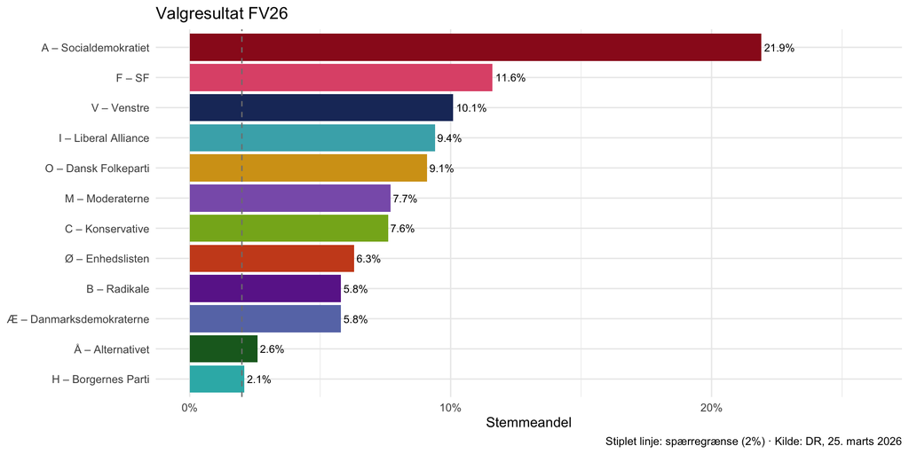

Valgresultat FV26 (dr.dk, 25. marts 2026)

```r
valgresultat <- tribble(
  ~parti,                  ~bogstav, ~pct,  ~farve,
  "Socialdemokratiet",     "A",      21.9,  "#9B1820",  # mørk karmesinrød
  "SF",                    "F",      11.6,  "#E05878",  # rosa/lyserød
  "Venstre",               "V",      10.1,  "#1E3568",  # mørk marineblå
  "Liberal Alliance",      "I",       9.4,  "#45AFB8",  # teal
  "Dansk Folkeparti",      "O",       9.1,  "#D4A018",  # gylden gul
  "Moderaterne",           "M",       7.7,  "#8A60B8",  # lilla
  "Konservative",          "C",       7.6,  "#85B020",  # limegrøn
  "Enhedslisten",          "Ø",       6.3,  "#CC4D20",  # orange
  "Radikale",              "B",       5.8,  "#6B2898",  # mørk lilla
  "Danmarksdemokraterne",  "Æ",       5.8,  "#6878B5",  # blågrå/slate
  "Alternativet",          "Å",       2.6,  "#1A6825",  # mørkegrøn
  "Borgernes Parti",       "H",       2.1,  "#32B5B5"   # teal/cyan
)

valgresultat |>
  mutate(label = paste0(bogstav, " – ", parti)) |>
  ggplot() +
  aes(x = fct_reorder(label, pct), y = pct, fill = bogstav) +
  geom_col() +
  geom_text(aes(label = paste0(pct, "%")), hjust = -0.1, size = 3) +
  geom_hline(yintercept = 2, linetype = "dashed", color = "grey50") +
  scale_fill_manual(values = setNames(valgresultat$farve, valgresultat$bogstav)) +
  scale_y_continuous(labels = scales::label_percent(scale = 1)) +
  coord_flip(ylim = c(0, 26)) +
  labs(
    title = "Valgresultat FV26",
    x = NULL,
    y = "Stemmeandel",
    caption = "Stiplet linje: spærregrænse (2%) · Kilde: DR, 25. marts 2026"
  ) +
  theme_minimal() +
  guides(fill = "none")
```

## FV26 – seneste meningsmåling

**Kode**

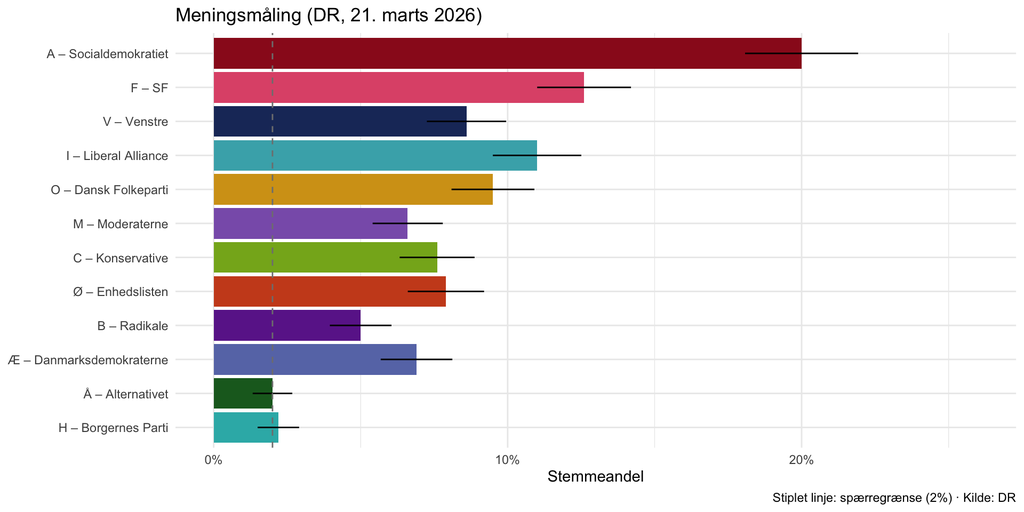

DR’s politiske indeks, 21. marts 2026 (n = 1.662)

```r
meningsmåling <- tribble(
  ~parti,                  ~bogstav, ~pct,  ~farve,
  "Socialdemokratiet",     "A",      20.0,  "#9B1820",  # mørk karmesinrød
  "SF",                    "F",      12.6,  "#E05878",  # rosa/lyserød
  "Liberal Alliance",      "I",      11.0,  "#45AFB8",  # teal
  "Dansk Folkeparti",      "O",       9.5,  "#D4A018",  # gylden gul
  "Venstre",               "V",       8.6,  "#1E3568",  # mørk marineblå
  "Enhedslisten",          "Ø",       7.9,  "#CC4D20",  # orange
  "Konservative",          "C",       7.6,  "#85B020",  # limegrøn
  "Danmarksdemokraterne",  "Æ",       6.9,  "#6878B5",  # blågrå/slate
  "Moderaterne",           "M",       6.6,  "#8A60B8",  # lilla
  "Radikale",              "B",       5.0,  "#6B2898",  # mørk lilla
  "Borgernes Parti",       "H",       2.2,  "#32B5B5",  # teal/cyan
  "Alternativet",          "Å",       2.0,  "#1A6825"   # mørkegrøn
)

meningsmåling |>
  left_join(valgresultat |> select(bogstav, resultat = pct), by = "bogstav") |>
  mutate(
    label  = paste0(bogstav, " – ", parti),
    p      = pct / 100,
    se     = sqrt(p * (1 - p) / 1662),
    ci_low = (p - 1.96 * se) * 100,
    ci_hi  = (p + 1.96 * se) * 100
  ) |>
  ggplot() +
  aes(x = fct_reorder(label, resultat), y = pct, fill = bogstav) +
  geom_col() +
  geom_linerange(aes(ymin = ci_low, ymax = ci_hi), color = "black") +
  geom_hline(yintercept = 2, linetype = "dashed", color = "grey50") +
  scale_fill_manual(values = setNames(meningsmåling$farve, meningsmåling$bogstav)) +
  scale_y_continuous(labels = scales::label_percent(scale = 1)) +
  coord_flip(ylim = c(0, 26)) +
  labs(
    title = "Meningsmåling (DR, 21. marts 2026)",
    x = NULL,
    y = "Stemmeandel",
    caption = "Stiplet linje: spærregrænse (2%) · Kilde: DR"
  ) +
  theme_minimal() +
  guides(fill = "none")
```

## FV26 – forskel / fejl

**Kode**

```r
p_diff <- meningsmåling |>
  left_join(valgresultat |> select(bogstav, resultat = pct), by = "bogstav") |>
  mutate(
    label   = paste0(bogstav, " – ", parti),
    forskel = resultat - pct,
    p      = pct / 100,
    se     = sqrt(p * (1 - p) / 1662),
    margin = 1.96 * se * 100          # same CI as poll plot, recentered at 0
  ) |>
  ggplot() +
  aes(x = fct_reorder(label, resultat), y = forskel, fill = bogstav) +
  geom_col() +
  geom_linerange(aes(ymin = -margin, ymax = margin),
                 color = "black", linewidth = 0.33) +
  geom_hline(yintercept = 0, color = "grey30") +
  scale_fill_manual(values = setNames(meningsmåling$farve, meningsmåling$bogstav)) +
  scale_y_continuous(labels = scales::label_percent(scale = 1)) +
  coord_flip(ylim = c(-5, 5)) +
  labs(
    title = "Forskel: valgresultat − meningsmåling",
    x = NULL,
    y = "Procentpoint",
    caption = "Positiv = parti klarede sig bedre end målingen · Kilde: DR"
  ) +
  theme_minimal() +
  guides(fill = "none")

p_diff
```

[output not shown]

## FV26 – forskel / fejl

- Meningsmålingen ramte nogenlunde præcist
- Men hvorfor er de aldrig helt præcise?

## Hvilken regering får vi?

→ [**https://chdausgaard.github.io/coalition-simulator/**](https://chdausgaard.github.io/coalition-simulator/)

# Tilfældighed og sandsynlighed

## Stokastiske variable

- **Stokastisk variabel**: En variabel, der er påvirket af *tilfældighed* og kan antage (mindst to) forskellige værdier, når den realiseres/observeres
- *Random variable* på engelsk
  - fx terning → 1,2,3,4,5,6
  - eller Socialdemokratiets vælgeropbakning ved næste valg → 0-100 %
- Ikke nødvendigvis “100% tilfældig”, men *ukendt/usikker*, før den realiseres/observeres
- Kan være **kontinuert** (temperaturen på valgdagen) eller **diskret** (antal børn)
- Også kendetegnet ved, at de mulige udfald kan beskrives med en **sandsynlighed**
- Sandsynligheden har en **fordeling** – som beskriver usikkerheden ved variablen

## Sandsynlighed

- **Udfaldet** af en (stokastisk) variabel *X*:
  - den værdi, *X* får, når den realiseres (fx terning → 2)
- **Mulige udfald** (udfaldsrum):
  - alle værdier, som *X* *kunne* få (fx terning → 1,2,3,4,5,6)
- **Sandsynligheden** for et givet udfald:
  - andelen af alle observationer, der har et udfald, når *X* observeres/realiseres MANGE gange (→ ∞)
  - *frekventisk* definition af sandsynlighed

## Sandsynlighed

- **Terningekast:**
  - 6 mulige udfald med samme sandsynlighed
  - Sandsynligheden for at slå 6: $Pr = 1/6 ≈ .166$
  - Ved 1.000.000 slag forventer vi meget tæt ved 166.667 (17%) 6’ere
  - Omvendt: ved 3 slag kan alting ske (ellers var Yatzy ikke sjovt…)
  - Andelen af 6’ere konvergerer mod $1/6$ (~16,667%) når antallet af slag → $∞$

## Sandsynlighedsfordelinger

- En sandsynlighedsfordeling beskriver sandsynligheden for alle mulige udfald på en variabel, *X*
- Samme princip som for en observeret variabel – bare sandsynligheder for udfald (*hypotetisk*) frem for observerede udfald (*realiseret*)
- Vi kan beregne gennemsnittet af en sandsynlighedsfordeling præcis som gennemsnit af en variabel/talrække
  - og beskrive den med andre statistikker: standardafvigelse, median, min/max osv.
  - gennemsnittet i en sandsynlighedsfordeling kaldes også den **forventede værdi**

## Sandsynlighedsfordelinger

- *X* er diskret → diskret sandsynlighedsfordeling
  - kategorisk/ordinal/binær
  - visualisering: heltal på x-aksen med søjler (fx geom_histogram)
- *X* er kontinuert → kontinuert sandsynlighedsfordeling
  - intervalskaleret
  - visualisering: kontinuum på x-aksen med kurve (fx geom_density)

## Diskrete sandsynlighedsfordelinger

- **Terningkast** følger en diskret sandsynlighedsfordeling
- Gennemsnit:
  - $µ = ∑ yPr(y)$
  - summen af mulige udfald ganget med deres sandsynligheder
- terning:
  - $µ = 1 * 1/6 + 2 * 1/6 + ... + 6 * 1/6 = \frac{21}{6} = 3.5$
  - 3.5 er midtpunktet mellem 1 og 6
- **Møntkast** er et andet eksempel på en stokastisk variabel, der følger en diskret sandsynlighedsfordeling:

## Plat og krone: antal *krone* ved 1 møntkast

**Kode**

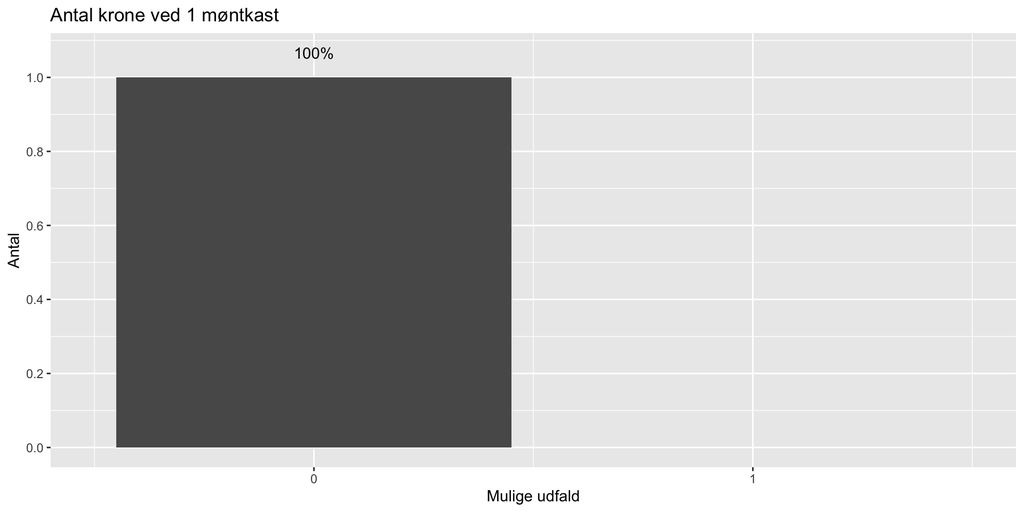

```r
set.seed(20260324)
n <- 1 # møntkast
sims <- 1 # simuleringer (1 - ∞)
resultater <- replicate(sims, sum(sample(c(0, 1), size = n, replace = TRUE)))

resultater |>
  as_tibble() |>
  count(value) |>
  mutate(p = n / sum(n)) |>
  ggplot() +
  aes(x = value, y = n) +
  geom_col() +
  geom_text(aes(y = n + max(n) / 15, label = str_glue("{round(p * 100)}%"))) +
  labs(
    title = str_glue("Antal krone ved {n} møntkast"),
    x = "Mulige udfald",
    y = "Antal"
  ) +
  scale_x_continuous(breaks = 0:n, limits = c(-0.5, n + 0.5)) +
  scale_y_continuous(breaks = scales::breaks_pretty())
```

## Plat og krone: antal *krone* ved 1 møntkast

**Kode**

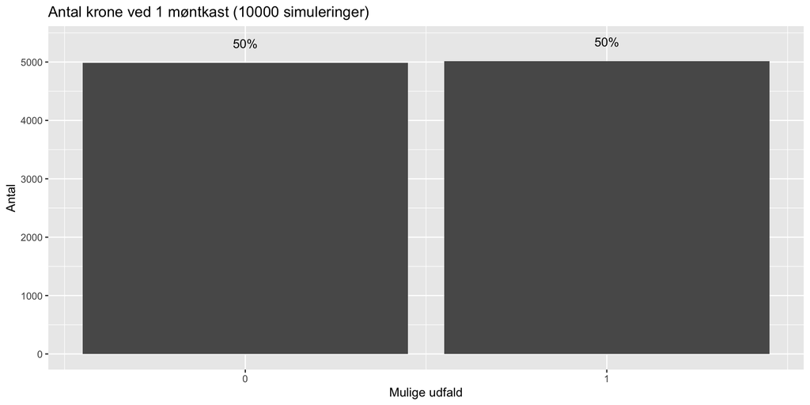

```r
set.seed(20260324)
n <- 1 # møntkast
sims <- 10000 # simuleringer (1 - ∞)
resultater <- replicate(sims, sum(sample(c(0, 1), size = n, replace = TRUE)))

resultater |>
  as_tibble() |>
  count(value) |>
  mutate(p = n / sum(n)) |>
  ggplot() +
  aes(x = value, y = n) +
  geom_col() +
  geom_text(aes(y = n + max(n) / 15, label = str_glue("{round(p * 100)}%"))) +
  labs(
    title = str_glue("Antal krone ved {n} møntkast ({sims} simuleringer)"),
    x = "Mulige udfald",
    y = "Antal"
  ) +
  scale_x_continuous(breaks = 0:n) +
  scale_y_continuous(breaks = scales::breaks_pretty())
```

## Plat og krone: antal *krone* ved 2 møntkast

**Kode**

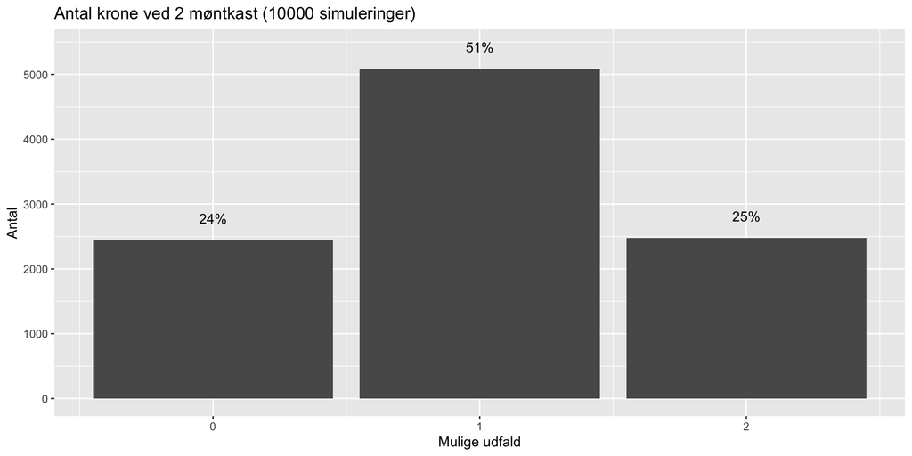

```r
set.seed(20260324)
n <- 2 # møntkast
sims <- 10000 # simuleringer (1 - ∞)
resultater <- replicate(sims, sum(sample(c(0, 1), size = n, replace = TRUE)))

resultater |>
  as_tibble() |>
  count(value) |>
  mutate(p = n / sum(n)) |>
  ggplot() +
  aes(x = value, y = n) +
  geom_col() +
  geom_text(aes(y = n + max(n) / 15, label = str_glue("{round(p * 100)}%"))) +
  labs(
    title = str_glue("Antal krone ved {n} møntkast ({sims} simuleringer)"),
    x = "Mulige udfald",
    y = "Antal"
  ) +
  scale_x_continuous(breaks = 0:n) +
  scale_y_continuous(breaks = scales::breaks_pretty())
```

## Plat og krone: antal *krone* ved 3 møntkast

**Kode**

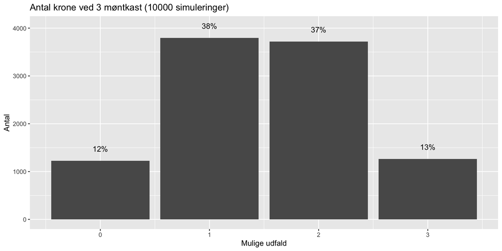

```r
set.seed(20260324)
n <- 3 # møntkast
sims <- 10000 # simuleringer (1 - ∞)
resultater <- replicate(sims, sum(sample(c(0, 1), size = n, replace = TRUE)))

resultater |>
  as_tibble() |>
  count(value) |>
  mutate(p = n / sum(n)) |>
  ggplot() +
  aes(x = value, y = n) +
  geom_col() +
  geom_text(aes(y = n + max(n) / 15, label = str_glue("{round(p * 100)}%"))) +
  labs(
    title = str_glue("Antal krone ved {n} møntkast ({sims} simuleringer)"),
    x = "Mulige udfald",
    y = "Antal"
  ) +
  scale_x_continuous(breaks = 0:n) +
  scale_y_continuous(breaks = scales::breaks_pretty())
```

## Plat og krone: antal *krone* ved 4 møntkast

**Kode**

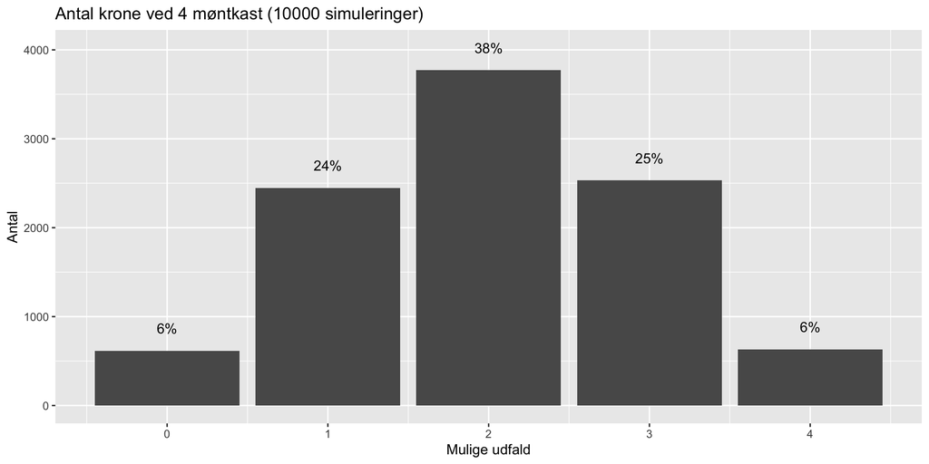

```r
set.seed(20260324)
n <- 4 # møntkast
sims <- 10000 # simuleringer (1 - ∞)
resultater <- replicate(sims, sum(sample(c(0, 1), size = n, replace = TRUE)))

resultater |>
  as_tibble() |>
  count(value) |>
  mutate(p = n / sum(n)) |>
  ggplot() +
  aes(x = value, y = n) +
  geom_col() +
  geom_text(aes(y = n + max(n) / 15, label = str_glue("{round(p * 100)}%"))) +
  labs(
    title = str_glue("Antal krone ved {n} møntkast ({sims} simuleringer)"),
    x = "Mulige udfald",
    y = "Antal"
  ) +
  scale_x_continuous(breaks = 0:n) +
  scale_y_continuous(breaks = scales::breaks_pretty())
```

## Plat og krone: antal *krone* ved 5 møntkast

**Kode**

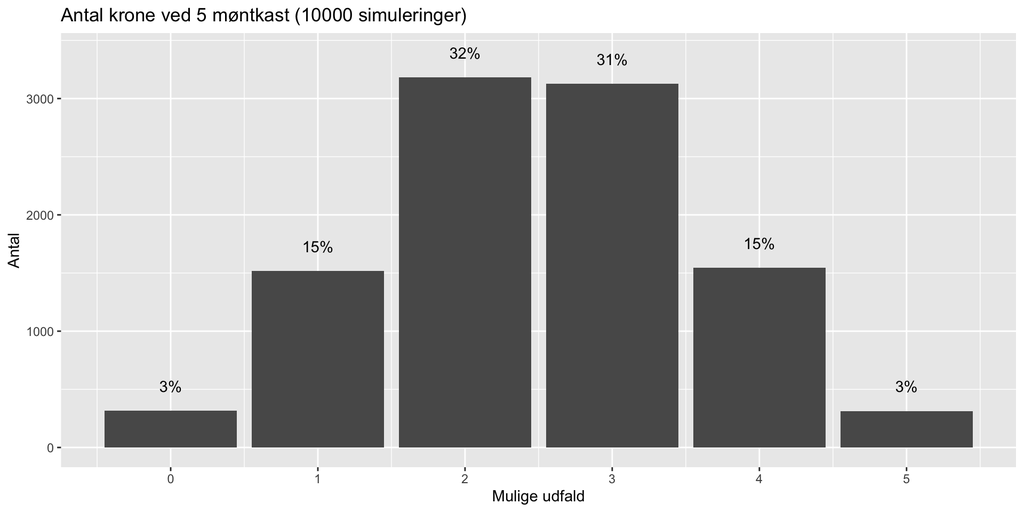

```r
set.seed(20260324)
n <- 5 # møntkast
sims <- 10000 # simuleringer (1 - ∞)
resultater <- replicate(sims, sum(sample(c(0, 1), size = n, replace = TRUE)))

resultater |>
  as_tibble() |>
  count(value) |>
  mutate(p = n / sum(n)) |>
  ggplot() +
  aes(x = value, y = n) +
  geom_col() +
  geom_text(aes(y = n + max(n) / 15, label = str_glue("{round(p * 100)}%"))) +
  labs(
    title = str_glue("Antal krone ved {n} møntkast ({sims} simuleringer)"),
    x = "Mulige udfald",
    y = "Antal"
  ) +
  scale_x_continuous(breaks = 0:n) +
  scale_y_continuous(breaks = scales::breaks_pretty())
```

## Plat og krone: antal *krone* ved 6 møntkast

**Kode**

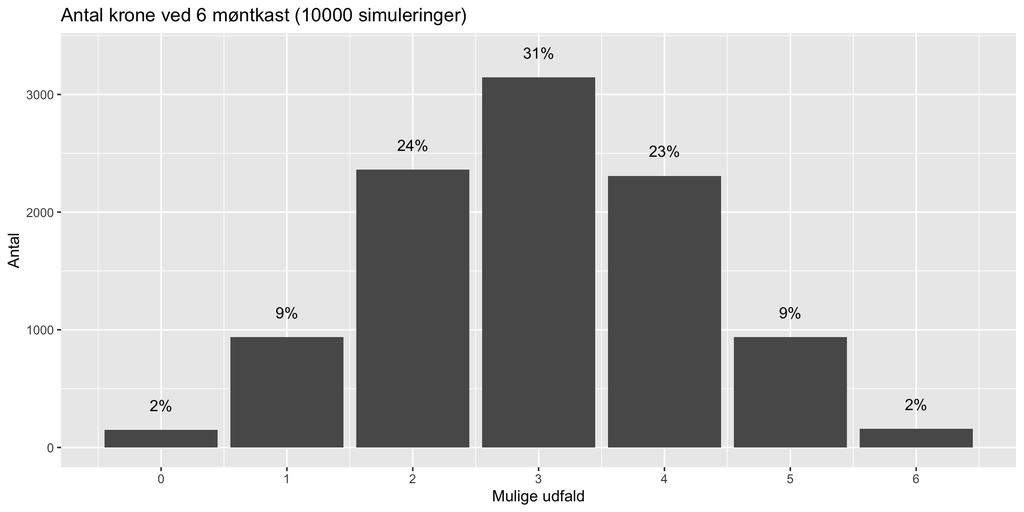

```r
set.seed(20260324)
n <- 6 # møntkast
sims <- 10000 # simuleringer (1 - ∞)
resultater <- replicate(sims, sum(sample(c(0, 1), size = n, replace = TRUE)))

resultater |>
  as_tibble() |>
  count(value) |>
  mutate(p = n / sum(n)) |>
  ggplot() +
  aes(x = value, y = n) +
  geom_col() +
  geom_text(aes(y = n + max(n) / 15, label = str_glue("{round(p * 100)}%"))) +
  labs(
    title = str_glue("Antal krone ved {n} møntkast ({sims} simuleringer)"),
    x = "Mulige udfald",
    y = "Antal"
  ) +
  scale_x_continuous(breaks = 0:n) +
  scale_y_continuous(breaks = scales::breaks_pretty())
```

## Plat og krone: antal *krone* ved 7 møntkast

**Kode**

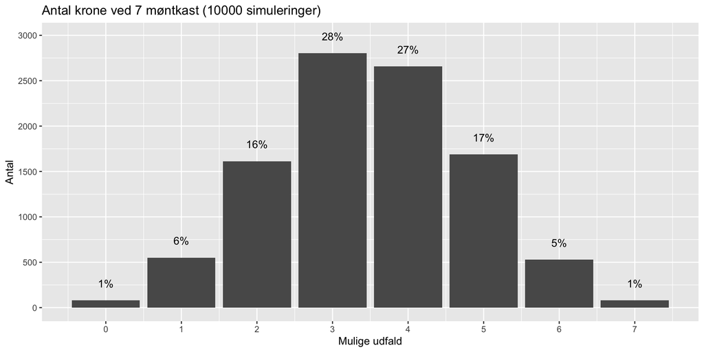

```r
set.seed(20260324)
n <- 7 # møntkast
sims <- 10000 # simuleringer (1 - ∞)
resultater <- replicate(sims, sum(sample(c(0, 1), size = n, replace = TRUE)))

resultater |>
  as_tibble() |>
  count(value) |>
  mutate(p = n / sum(n)) |>
  ggplot() +
  aes(x = value, y = n) +
  geom_col() +
  geom_text(aes(y = n + max(n) / 15, label = str_glue("{round(p * 100)}%"))) +
  labs(
    title = str_glue("Antal krone ved {n} møntkast ({sims} simuleringer)"),
    x = "Mulige udfald",
    y = "Antal"
  ) +
  scale_x_continuous(breaks = 0:n) +
  scale_y_continuous(breaks = scales::breaks_pretty())
```

## Plat og krone: antal *krone* ved 8 møntkast

**Kode**

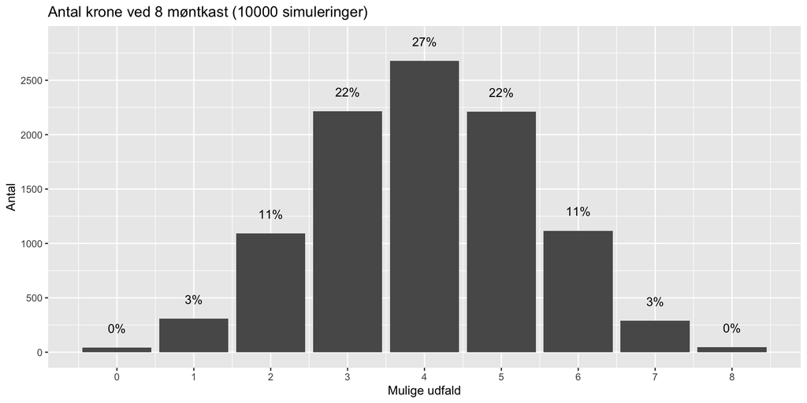

```r
set.seed(20260324)
n <- 8 # møntkast
sims <- 10000 # simuleringer (1 - ∞)
resultater <- replicate(sims, sum(sample(c(0, 1), size = n, replace = TRUE)))

resultater |>
  as_tibble() |>
  count(value) |>
  mutate(p = n / sum(n)) |>
  ggplot() +
  aes(x = value, y = n) +
  geom_col() +
  geom_text(aes(y = n + max(n) / 15, label = str_glue("{round(p * 100)}%"))) +
  labs(
    title = str_glue("Antal krone ved {n} møntkast ({sims} simuleringer)"),
    x = "Mulige udfald",
    y = "Antal"
  ) +
  scale_x_continuous(breaks = 0:n) +
  scale_y_continuous(breaks = scales::breaks_pretty())
```

## Plat og krone: antal *krone* ved 9 møntkast

**Kode**

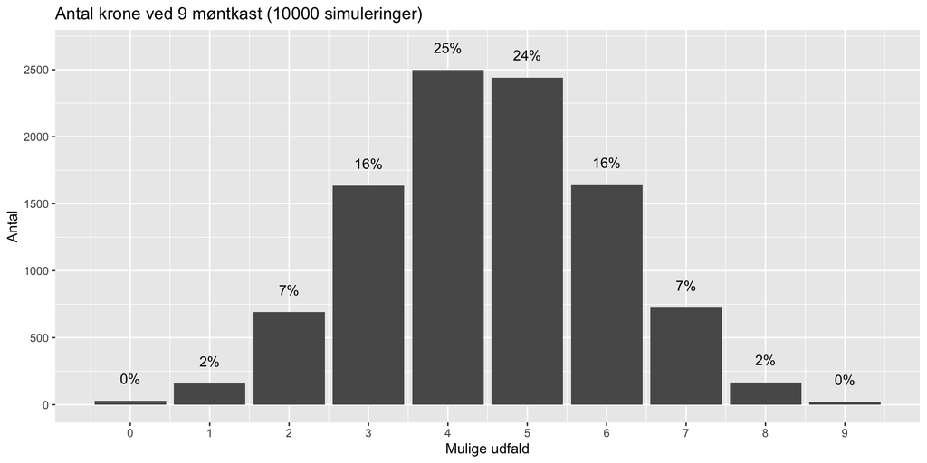

```r
set.seed(20260324)
n <- 9 # møntkast
sims <- 10000 # simuleringer (1 - ∞)
resultater <- replicate(sims, sum(sample(c(0, 1), size = n, replace = TRUE)))

resultater |>
  as_tibble() |>
  count(value) |>
  mutate(p = n / sum(n)) |>
  ggplot() +
  aes(x = value, y = n) +
  geom_col() +
  geom_text(aes(y = n + max(n) / 15, label = str_glue("{round(p * 100)}%"))) +
  labs(
    title = str_glue("Antal krone ved {n} møntkast ({sims} simuleringer)"),
    x = "Mulige udfald",
    y = "Antal"
  ) +
  scale_x_continuous(breaks = 0:n) +
  scale_y_continuous(breaks = scales::breaks_pretty())
```

## Plat og krone: antal *krone* ved 10 møntkast

**Kode**

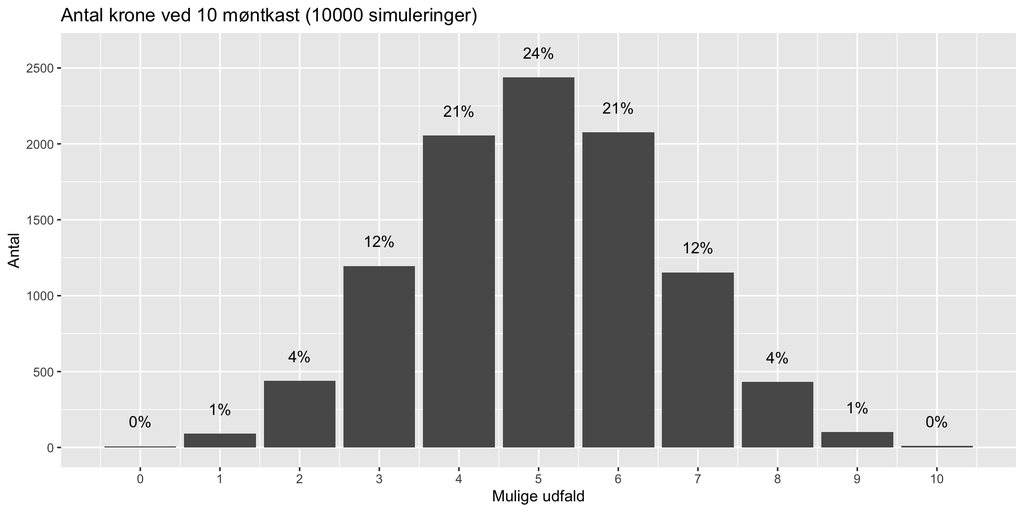

```r
set.seed(20260324)
n <- 10 # møntkast
sims <- 10000 # simuleringer (1 - ∞)
resultater <- replicate(sims, sum(sample(c(0, 1), size = n, replace = TRUE)))

resultater |>
  as_tibble() |>
  count(value) |>
  mutate(p = n / sum(n)) |>
  ggplot() +
  aes(x = value, y = n) +
  geom_col() +
  geom_text(aes(y = n + max(n) / 15, label = str_glue("{round(p * 100)}%"))) +
  labs(
    title = str_glue("Antal krone ved {n} møntkast ({sims} simuleringer)"),
    x = "Mulige udfald",
    y = "Antal"
  ) +
  scale_x_continuous(breaks = 0:n) +
  scale_y_continuous(breaks = scales::breaks_pretty())
```

## Bemærk to ting

1. Vi kan direkte se – og dermed vide – hvad sandsynligheden er for at få *et bestemt antal krone* ved et givent antal møntkast
   - mao. kender vi **sandsynligheden**, før vi kender udfaldet
2. Jo flere møntkast (gentagelser), desto mere **klokkeformet** bliver fordelingen
   - ikke tilfældigt → første glimt af *Den Centrale Grænseværdisætning*
   - bemærk at det samme sker, hvis vi gentager en hel undersøgelse mange gange
   - hvis vi øgede n mod ∞, ville søjlerne blive til en glat kurve: normalfordelingen

## Plat og krone: antal *krone* ved 10000 møntkast

**Kode**

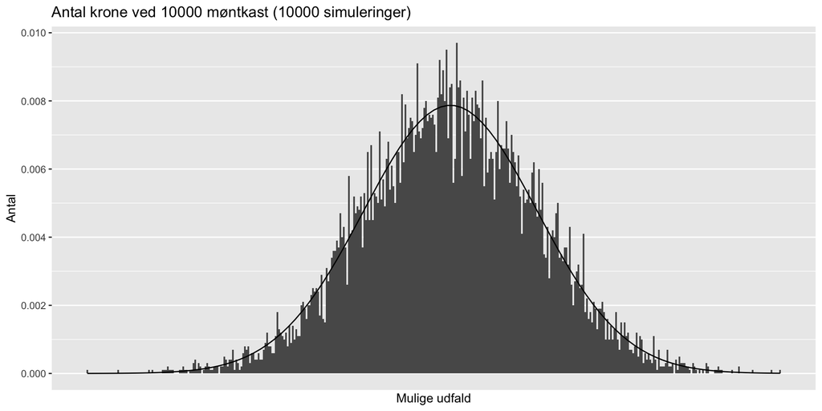

```r
set.seed(20260324)
n <- 10000 # møntkast
sims <- 10000 # simuleringer (1 - ∞)
resultater <- replicate(sims, sum(sample(c(0, 1), size = n, replace = TRUE)))

resultater |>
  as_tibble() |>
  ggplot() +
  aes(x = value) +
  geom_histogram(aes(y = after_stat(density)), binwidth = 1) +
  geom_function(fun = dnorm, args = list(mean = mean(resultater), sd = sd(resultater))) +
  labs(
    title = str_glue("Antal krone ved {n} møntkast ({sims} simuleringer)"),
    x = "Mulige udfald",
    y = "Antal"
  ) +
  scale_x_continuous(breaks = NULL) +
  scale_y_continuous(breaks = scales::breaks_pretty())
```

## Kontinuerte sandsynlighedsfordelinger

- Men hvad med tilfældige variable, der ikke er diskrete *counts* (antal)?
- Kontinuerte variable har **uendelige mulige udfald**
  - hvor mange penge tjener du i 2026?
- Vi kan ikke tilskrive hver eksakte værdi en sandsynlighed (der er for mange)

**I stedet:**

- **Intervaller af værdier/udfald** har en (samlet) sandsynlighed
  - hvad er sandsynligheden for at det bliver [1-2] grader varmere i morgen end normalen?
  - frem for sandsynligheden for 1.52159921519107091124368790

# Normalfordelingen

## Normalfordelingen

```r
tibble(x = -4:4) |>
ggplot() +
aes(x = x) +
stat_function(fun = dnorm, args = list(mean = 0, sd = 1))  +
scale_x_continuous(breaks = -4:4) +
labs(x = "z", y = "P")
```

[output not shown]

- “Bell-shaped”
- Symmetrisk omkring gennemsnittet
- **Hvad er gennemsnittet? Hvad er medianen? Hvad er typetallet?**
- Ikke skæv
- *Asymptotisk* i halerne (altså uendelig)

## Normalfordelingen

> “some probability distributions are important because they approximate well the distributions of variables in the real world”
- Eksempler på (approksimativt) **normalfordelte fænomener:**
  - *størrelse mv. på dyr og planter* (vægten af fisk, højden på mennesker)
  - *mentale attributter* (IQ, reaktionstider, testscorer)
  - *miljøfænomener* (temperaturer ift. normal)
  - *adfærd* (antal apps)
- Alternative **fordelinger:**
  - *uniform* (samme sandsynlighed, fx terning)
  - *binomial* (andel af “successer”, fx 6’ere)
  - *t-fordeling* (meget lig normal)

## 68-95-99-(tommelfinger)reglen:

> Andelen af observationer/sandsynlighedsmassen i normalfordelingen, der ligger inden for 1, 2, 3 standardafvigelser $σ$ fra fordelingens gennemsnit $µ$:
- **68 %** ligger inden for $µ ± 1σ$
- **95 %** ligger inden for $µ ± 2σ$
- **99 %** ligger inden for $µ ± 3σ$

**Kode**

```r
# beregning af nøjagtige værdier i R
pnorm(1) - pnorm(-1)
## [1] 0.6826895
pnorm(2) - pnorm(-2)
## [1] 0.9544997
pnorm(3) - pnorm(-3)
## [1] 0.9973002
```

## 68-95-99-(tommelfinger)reglen:

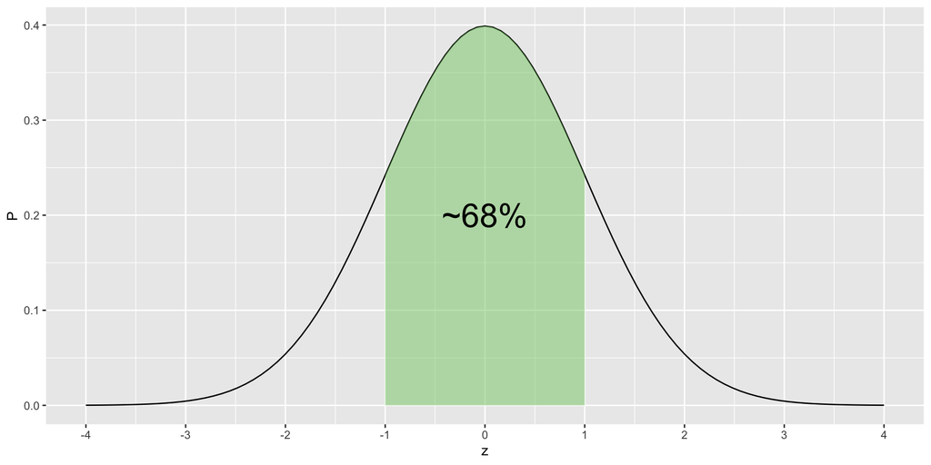

Normalfordelingen (gns. = 0, std.afv. = 1) – 68% af normalfordelingen

```r
tibble(x = -4:4) |>
ggplot() +
aes(x = x) +
stat_function(fun = dnorm, args = list(mean = 0, sd = 1))  +
stat_function(fun = dnorm, args = list(mean = 0, sd = 1), geom = "area", xlim = c(-1, 1), fill = "#84CA72", alpha = .5) +
annotate("text", x = 0, y = 0.2, label = "~68%", size = 9) +
scale_x_continuous(breaks = -4:4) +
labs(x = "z", y = "P")
```

## 68-95-99-(tommelfinger)reglen:

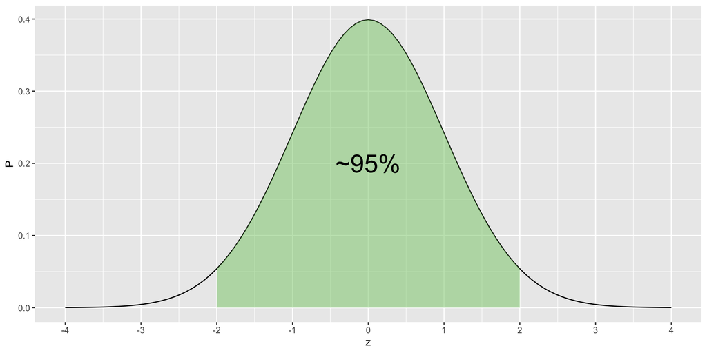

Normalfordelingen (gns. = 0, std.afv. = 1) – 95% af normalfordelingen

```r
tibble(x = -4:4) |>
ggplot() +
aes(x = x) +
stat_function(fun = dnorm, args = list(mean = 0, sd = 1))  +
stat_function(fun = dnorm, args = list(mean = 0, sd = 1), geom = "area", xlim = c(-2, 2), fill = "#84CA72", alpha = .5) +
annotate("text", x = 0, y = 0.2, label = "~95%", size = 9) +
scale_x_continuous(breaks = -4:4) +
labs(x = "z", y = "P")
```

## 68-95-99-(tommelfinger)reglen:

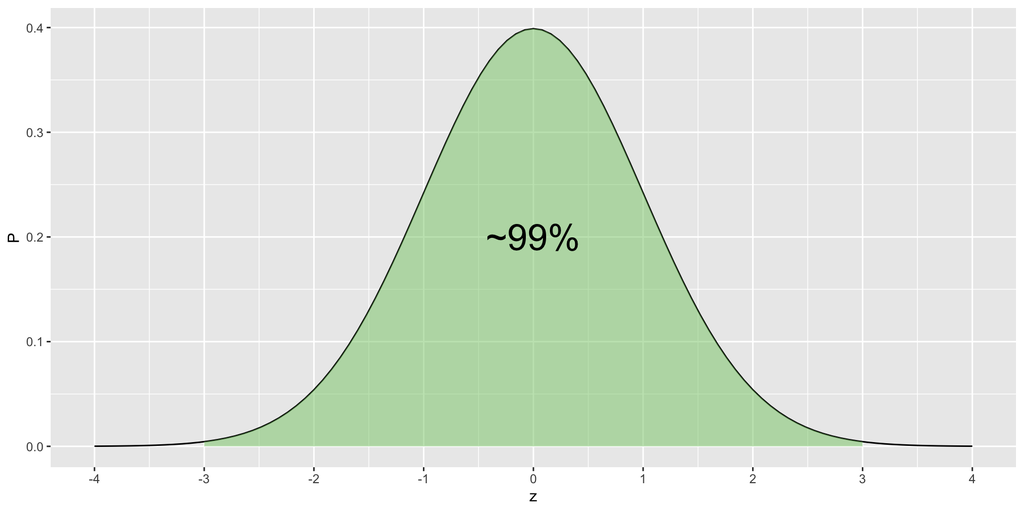

Normalfordelingen (gns. = 0, std.afv. = 1) – 99% af normalfordelingen

```r
tibble(x = -4:4) |>
ggplot() +
aes(x = x) +
stat_function(fun = dnorm, args = list(mean = 0, sd = 1))  +
stat_function(fun = dnorm, args = list(mean = 0, sd = 1), geom = "area", xlim = c(-3, 3), fill = "#84CA72", alpha = .5) +
annotate("text", x = 0, y = 0.2, label = "~99%", size = 9) +
scale_x_continuous(breaks = -4:4) +
labs(x = "z", y = "P")
```

## 68-95-99-(tommelfinger)reglen:

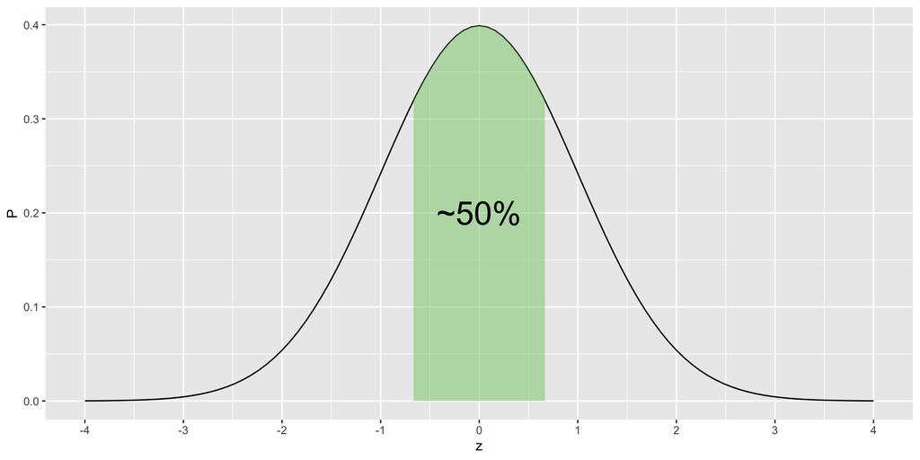

Normalfordelingen (gns. = 0, std.afv. = 1) – 50% af normalfordelingen

```r
tibble(x = -4:4) |>
ggplot() +
aes(x = x) +
stat_function(fun = dnorm, args = list(mean = 0, sd = 1))  +
stat_function(fun = dnorm, args = list(mean = 0, sd = 1), geom = "area", xlim = c(-2/3, 2/3), fill = "#84CA72", alpha = .5) +
annotate("text", x = 0, y = 0.2, label = "~50%", size = 9) +
scale_x_continuous(breaks = -4:4) +
labs(x = "z", y = "P")
```

## 68-95-99-(tommelfinger)reglen:

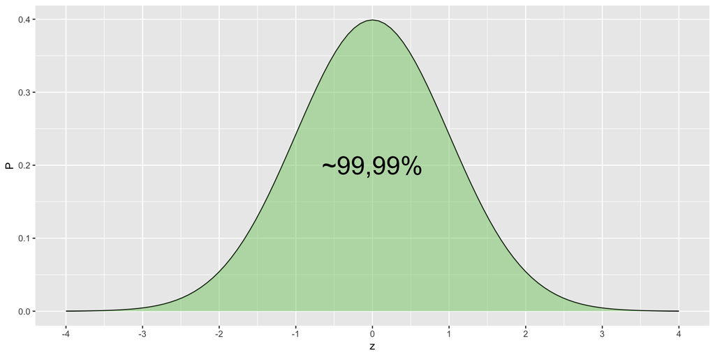

Normalfordelingen (gns. = 0, std.afv. = 1) – 99,99% af normalfordelingen

[figure not shown]

```r
tibble(x = -4:4) |>
ggplot() +
aes(x = x) +
stat_function(fun = dnorm, args = list(mean = 0, sd = 1))  +
stat_function(fun = dnorm, args = list(mean = 0, sd = 1), geom = "area", xlim = c(-4, 4), fill = "#84CA72", alpha = .5) +
annotate("text", x = 0, y = 0.2, label = "~99,99%", size = 9) +
scale_x_continuous(breaks = -4:4) +
labs(x = "z", y = "P")
```

## Eksempel: IQ

- **IQ** i befolkningen er approks. normalfordelt
  - $µ ≈ 100$
  - $σ ≈ 15$
- 68-95-99-reglen → 95 % af os har en IQ på $100 ± 2 × 15$
  - dvs. mellem 70 og 130
- Sandsynligheden for at have en **IQ højere end 130** = $\frac{1 − 0,95}{2} = 0,025$
  - dvs. 2,5 %
  - samme for Pr(under 70) → 2,5 %

## Z-værdier

- Afvigelser fra gennemsnittet i en normalfordeling kan beregnes som en **z-værdi**
- Alle z-værdier har en sandsynlighed → Pr(*z* eller derover/derunder)
- *z* er observationens afvigelse fra variablens gennemsnit udtrykt i antal standardafvigelser
- $z = \frac{y − µ}{\sigma}$
- Givet en normalfordeling med $µ = 100$ og $\sigma = 15$:
  - har scoren *130* z-værdien $\frac{130 - 100}{15} = 2$
  - har scoren *160* z-værdien $\frac{160 - 100}{15} = 4$
- Omskalerer værdierne, så de matcher *standardnormalfordelingen* ($µ = 0$, $\sigma = 1$)
- Alle intervalskalerede variable kan oversættes til z-værdier → kaldes **standardisering**

## Standardisering af variabel i R

```r
# lav en variabel, der går fra 0 til 10
tibble(var = 0:10) |>
# standardisér
mutate(gns = mean(var),
        sd = sd(var),
        z_manu = (var - gns) / sd,
        z_auto = as.double(scale(var))) |>
kable(digits = 2)
```

| var | gns | sd | z_manu | z_auto |
| --- | --- | --- | --- | --- |
| 0 | 5 | 3.32 | -1.51 | -1.51 |
| 1 | 5 | 3.32 | -1.21 | -1.21 |
| 2 | 5 | 3.32 | -0.90 | -0.90 |
| 3 | 5 | 3.32 | -0.60 | -0.60 |
| 4 | 5 | 3.32 | -0.30 | -0.30 |
| 5 | 5 | 3.32 | 0.00 | 0.00 |
| 6 | 5 | 3.32 | 0.30 | 0.30 |
| 7 | 5 | 3.32 | 0.60 | 0.60 |
| 8 | 5 | 3.32 | 0.90 | 0.90 |
| 9 | 5 | 3.32 | 1.21 | 1.21 |
| 10 | 5 | 3.32 | 1.51 | 1.51 |

## Standardisering af variabel i R

```r
# udvælg aldersvariablen i valgundersøgelsen
vu |>
select(alder = alder_på_valgdag) |>
filter(!is.na(alder)) |>
# standardisér
mutate(gns = mean(alder),
        sd = sd(alder),
        z_manu = (alder - gns) / sd,
        z_auto = as.double(scale(alder))) |>
sample_n(11) |>
arrange(alder) |>
kable(digits = 2)
```

| alder | gns | sd | z_manu | z_auto |
| --- | --- | --- | --- | --- |
| 25 | 52.95 | 18.47 | -1.51 | -1.51 |
| 27 | 52.95 | 18.47 | -1.40 | -1.40 |
| 30 | 52.95 | 18.47 | -1.24 | -1.24 |
| 33 | 52.95 | 18.47 | -1.08 | -1.08 |
| 38 | 52.95 | 18.47 | -0.81 | -0.81 |
| 50 | 52.95 | 18.47 | -0.16 | -0.16 |
| 59 | 52.95 | 18.47 | 0.33 | 0.33 |
| 60 | 52.95 | 18.47 | 0.38 | 0.38 |
| 79 | 52.95 | 18.47 | 1.41 | 1.41 |
| 80 | 52.95 | 18.47 | 1.46 | 1.46 |
| 80 | 52.95 | 18.47 | 1.46 | 1.46 |

## Z-værdier i R

- R kan fortælle os, hvor ekstrem en værdi er baseret på dens *z-værdi*:
  - `pnorm(1.33)`: 0.9082409
  - → hvor meget af normalfordelingen har en *mindre* z-værdi, end den angivne (arealet under kurven)
  - ~91 % har en z-værdi under 1.33
- Vi kan tilsvarende udregne, hvor meget der har en *højere* z-værdi
  - Summen af sandsynligheder er 1
  - `1 - pnorm(1.33):` 0.0917591
  - ~9 % har en z-værdi over 1.33
  - hvor mange % har så z < -1.33?

## Z-værdier i R

## Omvendt: fra sandsynlighed til z-værdi

- R kan også beregne, hvilken z-værdi der svarer til hvilken (kumulerede) sandsynlighed
- Fx hvor uklog man kan være og stadig være blandt de klogeste 10 %?
  - m.a.o.: hvad er den *mindste z-værdi* i den højeste *decil* (tiendedel) af normalfordelingen?
- `qnorm(p)` returnerer z-værdien for en given andel/sandsynlighed, *p*, i standardnormalfordelingen

```r
qnorm(.9) # 90%
```

```
[1] 1.281552
```

- 90 % har $z < 1.28$
- 10 % har $z > 1.28$
- Hvis din IQ svarer til $z = 1.28$, er din *ikke-standardiserede* IQ:
- $100 + 1.28 * 15 ≈ 119$

## Snak sammen

> Den gennemsnitlige testscore i en klasse er 60 med standardafvigelsen 10. *Du scorer 75.* Hvad er z-værdien for denne observation?

$z = \frac{y − µ}{\sigma}$

1. 0.74
2. 15
3. 1.5
4. 70
5. Kan ikke udregnes

## Snak sammen

> Er du kommet i top 10?

```r
pnorm(1.5)
```

```
[1] 0.9331928
```

```r
1 - pnorm(1.5)
```

```
[1] 0.0668072
```

# Stikprøvemålsfordelingen

## Stikprøvemålsfordelingen

- På engelsk “sampling distribution”
- Teori om vores samplingprocedure
- “Stikprøvemål” kan være mange forskellige statistikker beregnet i en stikprøve
  - vi fokuserer på gennemsnit
  - dvs. at stikprøven opsummeres som udgangspunkt i ét enkelt tal  
    → gennemsnittet af en variabel
  - fx gennemsnitlig *højre-venstre-placering* eller *alder*
- **Stikprøvemålsfordelingen** en teoretisk abstraktion, som vi ikke kan observere
  - vi har (som regel) blot *ét enkelt gennemsnit*
  - men havde vi fortsat med at tage *nye stikprøver*, ville vi få flere og flere
- Hvordan ser sandsynlighedsfordelingen for mulige stikprøvemål ud?
  - afhænger af (1) stikprøvestørrelsen og (2) typen af stikprøvemål

## Tre typer fordelinger

1. Populationsfordeling – en (ukendt) variabel
2. Stikprøvefordeling / *sample* distribution – en (kendt) variabel
3. Stikprøve*måls*fordeling / *sampling* distribution – gennemsnittet af en variabel

#### (1) Populationsfordeling

- fordeling af en variabel i **populationen**
- fx **befolkningens alder** (fordeling af værdier: ~0–122)

#### (2) Stikprøvefordeling

- fordeling af *samme variabel* i en enkelt (tilfældig) **stikprøve** fra populationen
- *n* (stikprøve)  
  < *N* (population)
- alder i **stikprøven** (fordeling af værdier: ~0–122 – *ligner* lidt populationen, men er ikke magen til)

#### (3) Stikprøvemålsfordeling

- sandsynlighedsfordeling for (fx) mulige *gennemsnit af en variabel i et undeligt antal stikprøver*
- fordeling af **mulige gennemsnitsaldre**
- givet mange stikprøver med *n* enheder
- fortæller os noget om forholdet mellem (1) og (2)

## Population: alder (simuleret)

**Kode**

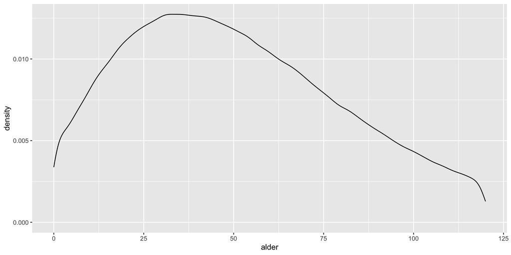

Populationsfordeling for alder (simuleret)

```r
set.seed(50)
pop <- tibble(alder = rnorm(n = 1000000,
                          mean = 50,
                          sd = 18)) |>
mutate(alder = alder^2 / 50) |>
filter(alder < 120)

pop |>
ggplot() +
aes(x = alder) +
geom_density()
```

## Stikprøve 1

**Kode**

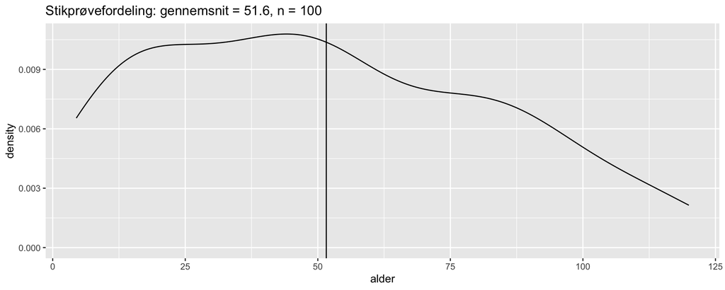

```r
sample1 <- pop |> # tilfældig stikprøve (n = 100)
sample_n(100)

sample1 |>
ggplot() +
aes(x = alder) +
geom_density() +
geom_vline(xintercept = mean(sample1$alder)) +
labs(title = paste0("Stikprøvefordeling: gennemsnit = ", round(mean(sample1$alder), 1), ", n = 100"))
```

## Stikprøve 2

**Kode**

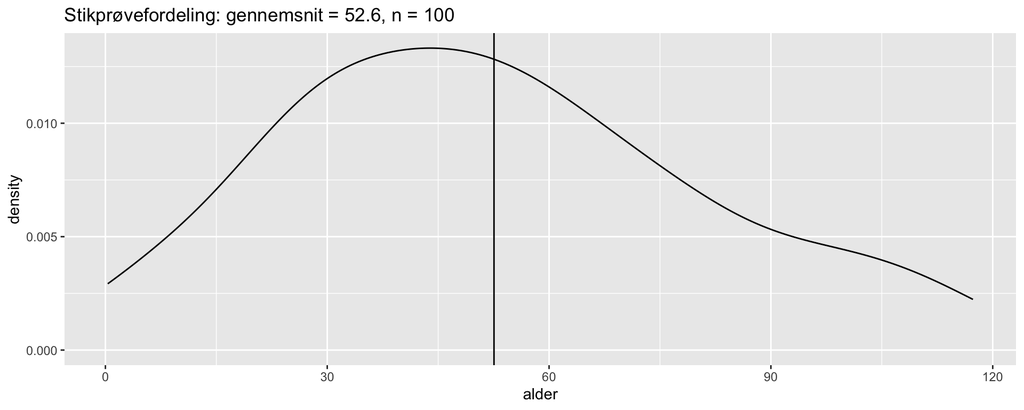

```r
sample2 <- pop |> # tilfældig stikprøve (n = 100)
sample_n(100)

sample2 |>
ggplot() +
aes(x = alder) +
geom_density() +
geom_vline(xintercept = mean(sample2$alder)) +
labs(title = paste0("Stikprøvefordeling: gennemsnit = ", round(mean(sample2$alder), 1), ", n = 100"))
```

## Stikprøve 3

**Kode**

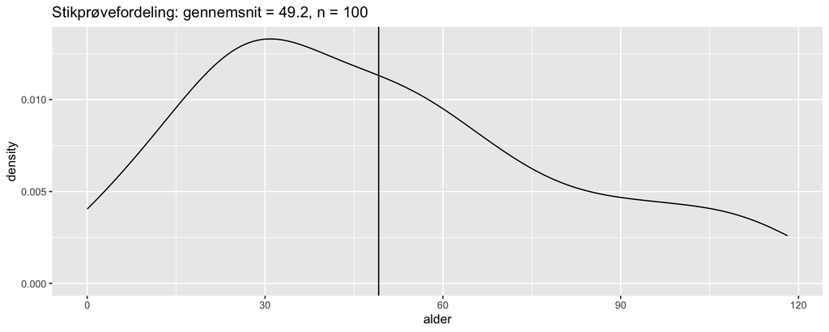

```r
sample3 <- pop |> # tilfældig stikprøve (n = 100)
sample_n(100)

sample3 |>
ggplot() +
aes(x = alder) +
geom_density() +
geom_vline(xintercept = mean(sample3$alder)) +
labs(title = paste0("Stikprøvefordeling: gennemsnit = ", round(mean(sample3$alder), 1), ", n = 100"))
```

## Stikprøve 4

**Kode**

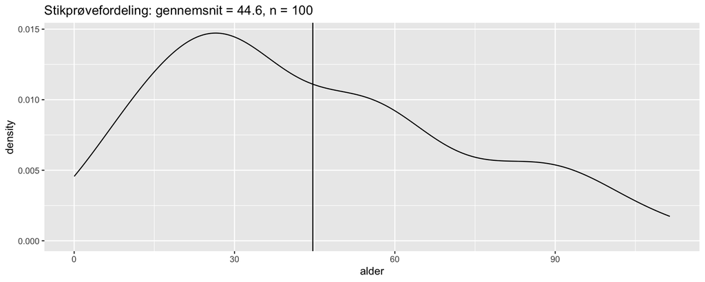

```r
sample4 <- pop |> # tilfældig stikprøve (n = 100)
sample_n(100)

sample4 |>
ggplot() +
aes(x = alder) +
geom_density() +
geom_vline(xintercept = mean(sample4$alder)) +
labs(title = paste0("Stikprøvefordeling: gennemsnit = ", round(mean(sample4$alder), 1), ", n = 100"))
```

## Stikprøve 5

**Kode**

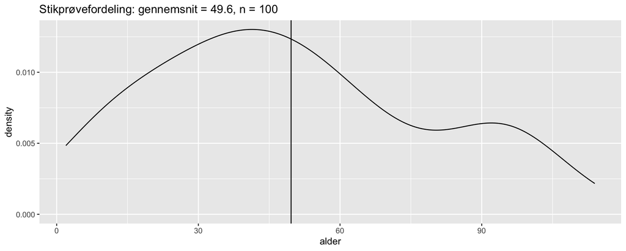

```r
sample5 <- pop |> # tilfældig stikprøve (n = 100)
sample_n(100)

sample5 |>
ggplot() +
aes(x = alder) +
geom_density() +
geom_vline(xintercept = mean(sample5$alder)) +
labs(title = paste0("Stikprøvefordeling: gennemsnit = ", round(mean(sample5$alder), 1), ", n = 100"))
```

## Gennemsnitsalder

- Populationsgennemsnit: ca. 50 år (ukendt parameter)
- *Stikprøvegennemsnit (opsummering):*
  - 1 ≈ 52
  - 2 ≈ 53
  - 3 ≈ 49
  - 4 ≈ 45
  - 5 ≈ 50
  - . . .
  - 999999 ≈ ???
- Lad os prøve at udtage MANGE stikprøver i R …

## Gentag sampling 5 gange og plot

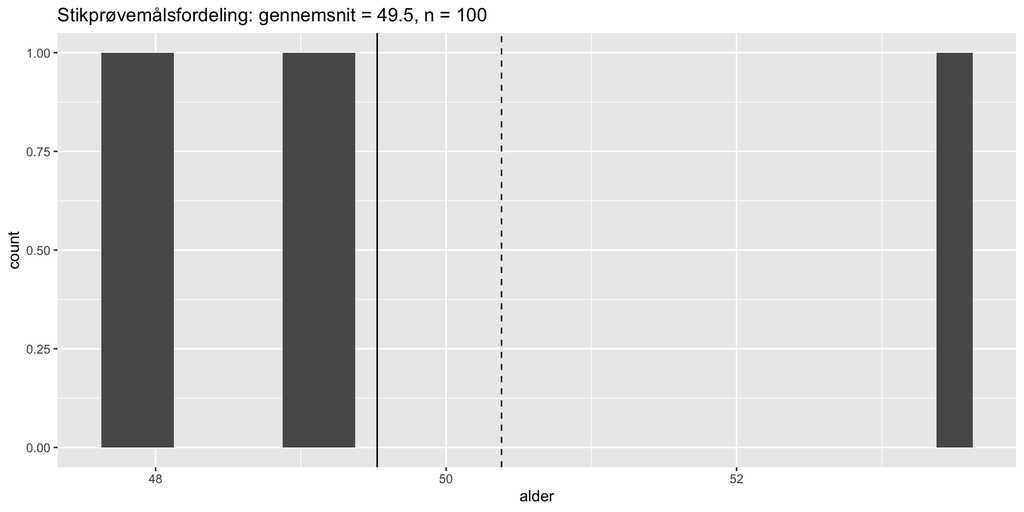

Stikprøvemålsfordeling (gennemsnit) – sampling gentaget 5 gange

```r
gns_list <- map(1:5,
  ~ pop |>
    sample_n(100) |>  # n = 100!
    pull(alder) |>
    mean())

gns <- tibble(alder = unlist(gns_list))

gns |>
ggplot() +
aes(x = alder) +
geom_histogram(binwidth = .25) +
geom_vline(xintercept = mean(gns$alder)) +
geom_vline(xintercept = mean(pop$alder), linetype = "dashed") +
labs(title = paste0("Stikprøvemålsfordeling: gennemsnit = ", round(mean(gns$alder), 1), ", n = 100"))
```

## Gentag sampling 30 gange og plot

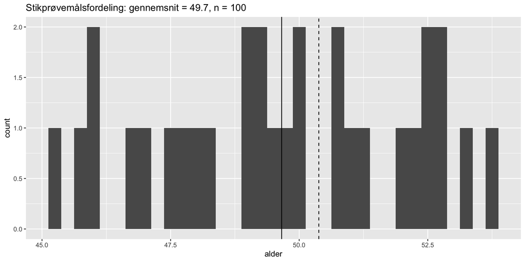

Stikprøvemålsfordeling (gennemsnit) – sampling gentaget 30 gange

```r
gns_list <- map(1:30,
  ~ pop |>
    sample_n(100) |>  # n = 100!
    pull(alder) |>
    mean())

gns <- tibble(alder = unlist(gns_list))

gns |>
ggplot() +
aes(x = alder) +
geom_histogram(binwidth = .25) +
geom_vline(xintercept = mean(gns$alder)) +
geom_vline(xintercept = mean(pop$alder), linetype = "dashed") +
labs(title = paste0("Stikprøvemålsfordeling: gennemsnit = ", round(mean(gns$alder), 1), ", n = 100"))
```

## Gentag sampling 300 gange og plot

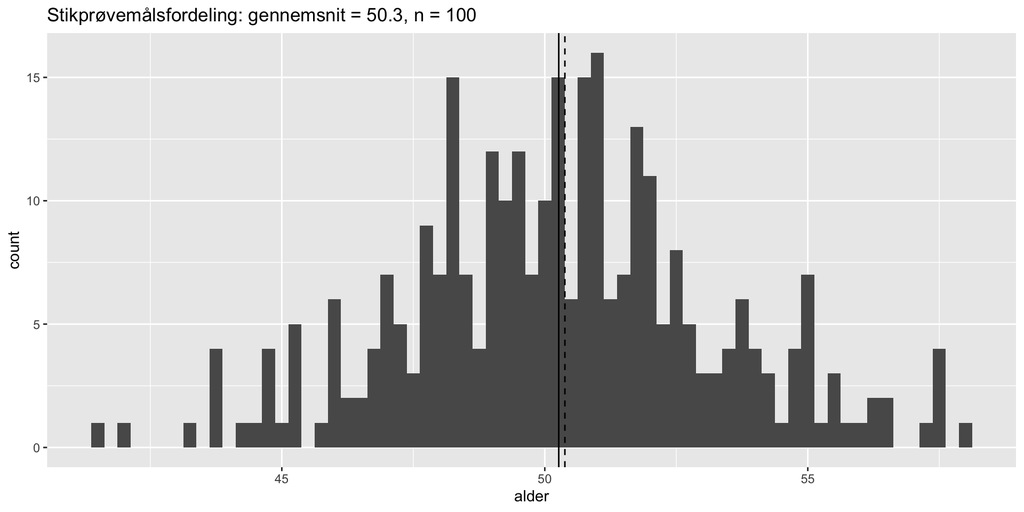

Stikprøvemålsfordeling (gennemsnit) – sampling gentaget 300 gange

```r
gns_list <- map(1:300,
  ~ pop |>
    sample_n(100) |>  # n = 100!
    pull(alder) |>
    mean())

gns <- tibble(alder = unlist(gns_list))

gns |>
ggplot() +
aes(x = alder) +
geom_histogram(binwidth = .25) +
geom_vline(xintercept = mean(gns$alder)) +
geom_vline(xintercept = mean(pop$alder), linetype = "dashed") +
labs(title = paste0("Stikprøvemålsfordeling: gennemsnit = ", round(mean(gns$alder), 1), ", n = 100"))
```

## Gentag sampling 3000 gange og plot

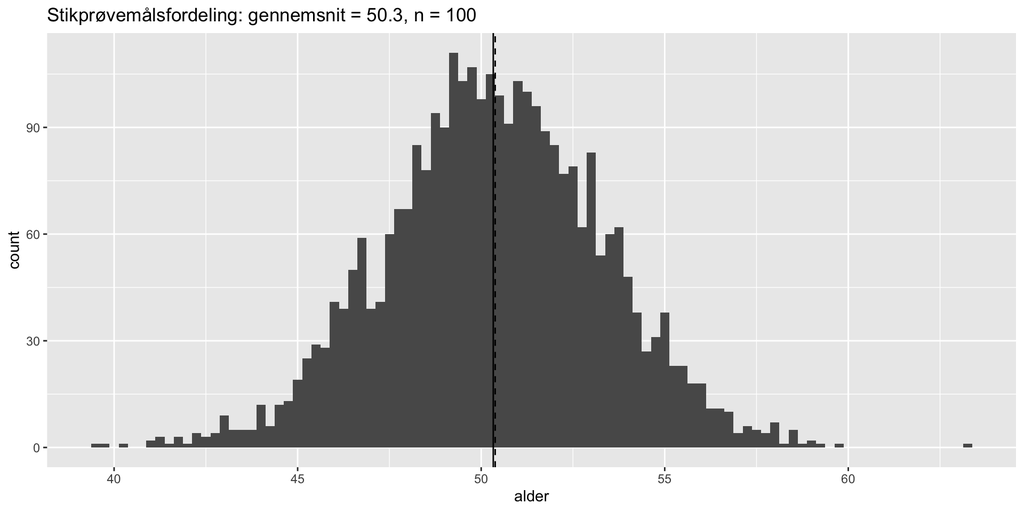

Stikprøvemålsfordeling (gennemsnit) – sampling gentaget 3000 gange

```r
gns_list <- map(1:3000,
  ~ pop |>
    sample_n(100) |>  # n = 100!
    pull(alder) |>
    mean())

gns <- tibble(alder = unlist(gns_list))

gns |>
ggplot() +
aes(x = alder) +
geom_histogram(binwidth = .25) +
geom_vline(xintercept = mean(gns$alder)) +
geom_vline(xintercept = mean(pop$alder), linetype = "dashed") +
labs(title = paste0("Stikprøvemålsfordeling: gennemsnit = ", round(mean(gns$alder), 1), ", n = 100"))
```

## Gentag sampling 10000 gange og plot

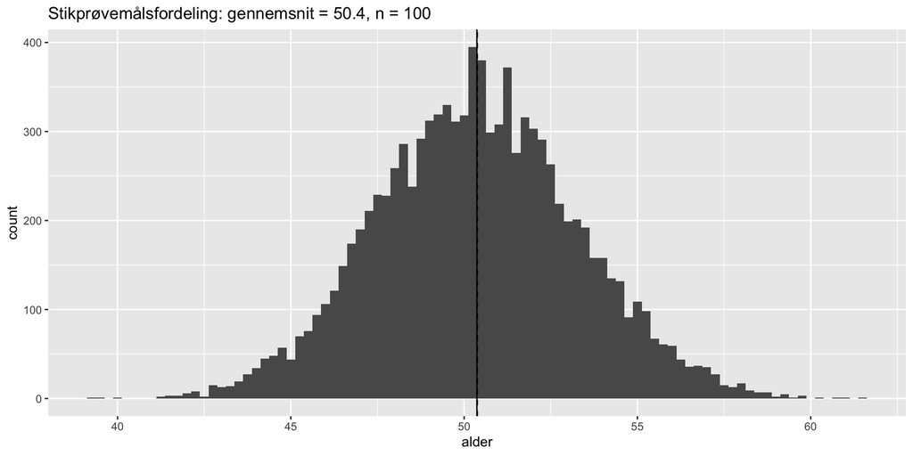

Stikprøvemålsfordeling (gennemsnit) – sampling gentaget 10000 gange

```r
gns_list <- map(1:10000,
  ~ pop |>
    sample_n(100) |>  # n = 100!
    pull(alder) |>
    mean())

gns <- tibble(alder = unlist(gns_list))

p <- gns |>
ggplot() +
aes(x = alder) +
geom_histogram(binwidth = .25) +
geom_vline(xintercept = mean(gns$alder)) +
geom_vline(xintercept = mean(pop$alder), linetype = "dashed") +
labs(title = paste0("Stikprøvemålsfordeling: gennemsnit = ", round(mean(gns$alder), 1), ", n = 100"))

p
```

## Gentag sampling 10000 gange og plot

**Kode**

```r
p
```

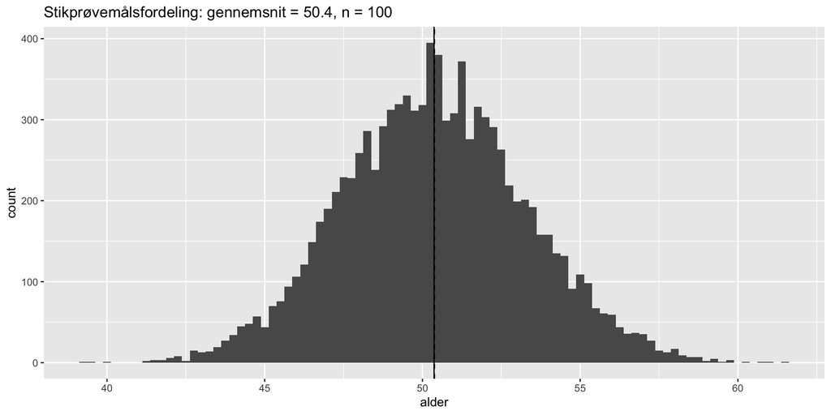

Stikprøvemålsfordeling (gennemsnit) – sampling gentaget 10000 gange

# Dette leder os frem til **magien** bag statistisk inferens

## Den Centrale Grænseværdisætning (*Central Limit Theorem*, CLT)

Uanset hvordan variablen er fordelt i **populationen**,og  
uanset hvordan variablen er fordelt i **stikprøven**, gælder det at

## Den Centrale Grænseværdisætning (*Central Limit Theorem*, CLT)

Uanset hvordan variablen er fordelt i **populationen**,og  
uanset hvordan variablen er fordelt i **stikprøven**, gælder det at

> Stikprøvemålsfordelingen for stikprøvens gennemsnit er **altid (approks.) normalfordelt**, når stikprøven er stor<sup>1</sup>
- “Stor” stikprøve: *n > 30* (tommelfingerregel)
- **CLT** er en vigtig statistisk/matematisk “opdagelse”
  - gælder *i teorien* for “an infinite number of random samples” (asymptotisk)
  - gælder *i praksis* meget ofte
  - fritager os fra en masse bøvl og krævende antagelser
[^1]: “For random sampling with a large sample size *n*, the sampling distribution of the sample mean $\bar{y}$ is approximately a normal distribution” (Agresti & Finlay 2014: 93).

## Den Centrale Grænseværdisætning (*Central Limit Theorem*, CLT)

> Stikprøvemålsfordelingen for stikprøvens gennemsnit er **altid (approks.) normalfordelt**, når stikprøven er stor
- **CLT** gælder for mange “stikprøvemål”:
  - *gennemsnit* (kontinuert variabel)
  - *andel* (gennemsnit af *binær* variabel)
  - *sum*
  - *forskel* mellem to grupper (samme variabel) eller mellem to variable
  - *lineær sammenhæng* mellem to variable (korrelations-/regressionskoefficienter)
- Men ikke alle stikprøvemål (fx ikke medianen)

## Illustration af CLT

→ [**http://mfviz.com/central-limit/**](http://mfviz.com/central-limit/)

## Standardfejl

- **Stikprøvemålsfordelingen for gennemsnittet** er normalfordelt pga. CLT
- Denne viden kan bruges til at kvantificere afstanden mellem stikprøver og den “sande” værdi
- Til dette skal vi bruge stikprøvemålsfordelingens **standardafvigelse**
  - hvor langt falder stikprøvegennemsnittene typisk fra det sande populationsgennemsnit?
  - hvor stor er *spredningen* i mulige stikprøvegennemsnit?
- Denne kaldes **standardfejlen:**
  - $se = \frac {\sigma} {\sqrt{n}}$,  
    hvor $\sigma$ er std.afv. i populationen, og *n* er stikprøvestørrelsen

## Standardfejl: alder

- Alder (populationen):
  - $µ$ ≈ 50 år, $σ$ ≈ 30 år
- Alder (stikprøve 1, *n* = 100)
  - $\bar{y}$ ≈ 52 år, $s$ ≈ 32 år
- $se = \frac {\sigma} {\sqrt{n}} = ???$
- I praksis kender vi ikke $\sigma$ (std.afv. i *populationen*)
  - så vi *estimerer* den som *s* (std.afv. i *stikprøven*) → giver en smule ekstra usikkerhed
  - $\hat{se} = \frac {s} {\sqrt{n}}$

```r
m <- mean(sample1$alder) # gns.
s <- sd(sample1$alder)   # std.avg.
n <- nrow(sample1)       # stikprøvestr.
se <- s / sqrt(n)        # standardfejl

# vis gennemsnittet med standardfejlen i parantes
paste0(format(m, digits = 1, nsmall = 1), " (",
      format(se, digits = 1, nsmall = 1), ")")
```

```
[1] "51.6 (3.2)"
```

## Standardfejl: alder

- Standardfejlen udtrykker graden af (sampling)*usikkerhed*
- Vigtigt: at $\hat{se}$ er et produkt af *s* og *n* betyder, at
  - højere *s øger* standardfejlen
  - **højere *n mindsker* standardfejlen**
  - *n* kan nemmere kontrolleres end *s*
  - → større stikprøver er *alt andet lige* bedre